# Geospatial Risk Prediction

Shengao Yi

2022-10-21

## 1. Introduction

In San Francisco, there are 148209 crime reports recorded by the SF Police Department in 2019. Each incident record includes the call number, incident number, category, description, police district, longitude, latitude and so on. It not only does harm to civilian deaths or injuries, but also cause billion dollars lost in poverty damage.

To protect the public safety, poverty and people’s life, and also relieve the limited policing resources’ stress, it’s necessary for us to turn to data and creative algorithm methods for help. Hopefully, we have the database maintained. There is enough experience from places where crime incidents are observed. We can test whether that experience generalizes to places that may be at risk for crime, even if few events are reported.

So to complete the task, I propose a crime risk model which looks into the general but severe crime type - robbery. I selected six socio-economic risk factors that may be relevant to the crime incidents. Our model use regression techniques to predict the places crimes would occur, and thus can instruct the police to pay more attention to those places, also allow for more effective and efficient deployment of city resources. The model also considered the selection bias by studying neighborhood disparity effect, like unequal distribution of police force.

But we should be very carefully with the model. Because it can not tell us the accuracy places where crimes will happen in the future (no one knows). It’s a discrete event. Bias would happen all the process of model building, like data collection methods. Each department has their own method, which would cause different standards. Predictions from geospatial risk models can be thought of as latent risk - areas at risk even if a crime has not actually been reported there.

In the following section, I firstly download crime, boundary, neighborhoods data and so on from San Francisco Open Data website. Then, do some data wrangling to help us get a better understanding of these data and feature engineering to make preparations for prediction. In section 3, explore some spatial patterns and run the model, analyze and map the results.

```r
# Rmarkdown global setting
knitr::opts_chunk$set(echo = TRUE)
knitr::opts_chunk$set(message = FALSE)
knitr::opts_chunk$set(warning = FALSE)
knitr::opts_chunk$set(cache = TRUE)
knitr::opts_chunk$set(fig.align = 'center')

#----------------------------------------------------------------------------------------------------------

# Import libraries
library(tidyverse)
library(tidycensus)
library(sf)
library(spdep)
library(caret)
library(ckanr)
library(FNN)
library(grid)
library(gridExtra)
library(ggcorrplot)# plot correlation plot
library(corrplot)
library(corrr)      # another way to plot correlation plot
library(kableExtra)
library(jtools)     # for regression model plots
library(ggstance) # to support jtools plots
library(ggpubr)    # plotting R^2 value on ggplot point scatter
library(broom.mixed) # needed for effects plots
library(knitr)
library(rmarkdown)
library(RSocrata)
library(viridis)
library(ggplot2)
library(stargazer)
library(XML)
library(data.table)
library(ggpmisc)
library(patchwork)
library(spatstat)
library(raster)
library(classInt)   # for KDE and ML risk class intervals
library(tableHTML)

# Temp
source("https://raw.githubusercontent.com/urbanSpatial/Public-Policy-Analytics-Landing/master/functions.r")
root.dir = "https://raw.githubusercontent.com/urbanSpatial/Public-Policy-Analytics-Landing/master/DATA/"

# Etc
options(scipen=999)
options(tigris_class = "sf")


# functions

st_c    <- st_coordinates
st_coid <- st_centroid

mapThememin <- function(base_size = 10, title_size = 12, small_size = 8) {
  theme(
    text = element_text( color = "black"),
    plot.title = element_text(size = title_size, colour = "black", hjust = 0.5),
    plot.subtitle=element_text(size = base_size, colour = "black", hjust = 0.5, face="italic"),
    plot.caption=element_text(size = small_size, colour = "black", hjust = 0.5),
    axis.ticks = element_blank(),
    axis.title = element_blank(),
    axis.text = element_blank(),
    axis.title.x = element_blank(),
    axis.title.y = element_blank(),
    panel.background = element_blank(),
    panel.grid.minor = element_blank(),
    panel.border = element_blank(),
    strip.text.x = element_text(size = base_size),
    strip.text.y = element_text(size = base_size),
    strip.background = element_rect(colour="transparent", fill="transparent"),
    legend.title = element_text(size = small_size),
    legend.text = element_text(size = small_size),
    legend.key.size = unit(0.4, "cm"))
}


corTheme <- function(base_size = 10, title_size = 12, small_size = 8){
  theme(axis.text =  element_blank(),
        axis.ticks = element_blank(),
        text = element_text(size = 10),
        panel.background = element_rect(fill = greyPalette5[1]),
        axis.title.x = element_text(size = small_size),
        axis.title.y = element_text(size = small_size),
        plot.subtitle = element_text(hjust = 0.5, size = base_size),
        plot.title = element_text(hjust = 0.5, size = title_size),
        plot.caption=element_text(size = small_size, colour = "black", hjust = 0.5),
        strip.background = element_rect(colour="transparent", fill="transparent"))
}


corTheme2 <- function(base_size = 10, title_size = 12, small_size = 8){
  theme(axis.text =  element_text(size = small_size),
        text = element_text(size = 10),
        panel.background = element_rect(fill = greyPalette5[1]),
        axis.title.x = element_text(size = small_size),
        axis.title.y = element_text(size = small_size),
        plot.subtitle = element_text(hjust = 0.5, size = base_size,  face="italic"),
        plot.title = element_text(hjust = 0.5, size = title_size),
        plot.caption=element_text(size = small_size, colour = "black", hjust = 0.5),
        strip.background = element_rect(colour="transparent", fill="transparent"))
}

corTheme3 <- function(base_size = 9, title_size = 11, small_size = 7){
  theme(axis.text =  element_text(size = small_size),
        text = element_text(size = 10),
        panel.background = element_rect(fill = greyPalette5[1]),
        axis.title.x = element_text(size = small_size),
        axis.title.y = element_text(size = small_size),
        plot.subtitle = element_text(hjust = 0.5, size = base_size,  face="italic"),
        plot.title = element_text(hjust = 0.5, size = title_size),
        plot.caption=element_text(size = small_size, colour = "black", hjust = 0.5))
}

corTheme4 <- function(base_size = 9, title_size = 11, small_size = 7){
  theme(axis.text =  element_text(size = small_size),
        text = element_text(size = 10),
        panel.background = element_rect(fill = greyPalette5[1]),
        axis.title.x = element_text(size = small_size),
        axis.title.y.right = element_text(size = small_size),
        plot.subtitle = element_text(hjust = 0.5, size = base_size,  face="italic"),
        plot.title = element_text(hjust = 0.5, size = title_size),
        plot.caption=element_text(size = small_size, colour = "black", hjust = 0.5))
}


q5 <- function(variable) {as.factor(ntile(variable, 5))}

q <- function(variable) {as.factor(ntile(variable, 5))}

qBr <- function(df, variable, rnd) {
  if (missing(rnd)) {
    as.character(quantile(round(df[[variable]],0),
                          c(.01,.2,.4,.6,.8), na.rm=T))
  } else if (rnd == FALSE | rnd == F) {
    as.character(formatC(quantile(df[[variable]],
                                  c(.01,.2,.4,.6,.8), na.rm=T),
                         digits = 3))
  }
}

qBr2 <- function(df, variable, rnd) {
  if (missing(rnd)) {
    as.character(quantile(round(df[[variable]]*100,0)/100,
                          c(.01,.2,.4,.6,.8), na.rm=T))
  } else if (rnd == FALSE | rnd == F) {
    as.character(formatC(quantile(df[[variable]],
                                  c(.01,.2,.4,.6,.8), na.rm=T),
                         digits = 3))
  }
}

substrRight <- function(x, n){
  substr(x, nchar(x)-n+1, nchar(x))
}


nn_function <- function(measureFrom,measureTo,k) {
  measureFrom_Matrix <- as.matrix(measureFrom)
  measureTo_Matrix <- as.matrix(measureTo)
  nn <- get.knnx(measureTo, measureFrom, k)$nn.dist
  output <- as.data.frame(nn) %>%
    rownames_to_column(var = "thisPoint") %>%
    gather(points, point_distance, V1:ncol(.)) %>%
    arrange(as.numeric(thisPoint)) %>%
    group_by(thisPoint) %>%
    summarize(pointDistance = mean(point_distance)) %>%
    arrange(as.numeric(thisPoint)) %>%
    dplyr::select(-thisPoint) %>%
    pull()
  return(output)
}


# Colors ("https://coolors.co/gradient-palette/a8f368-f9035e?number=7")
bluePalette5 <- c("#eff3ff","#bdd7e7","#6baed6","#3182bd","#08519c")
blue2Palette5 <- c("#08519c","#3182bd","#6baed6","#bdd7e7","#eff3ff")
orangePalette5 <- c("#FFF2E8","#FFD6B6","#FEB984","#FE9D51","#FD801F")
orange2Palette5 <- c("#FFDFD0","#FFB89F","#FF926E","#FF6B3D","#FF440C")
greyPalette5 <- c("#f7f7f7","#cccccc","#969696","#636363","#252525")
greenPalette5 <- c("#edf8e9","#bae4b3","#74c476","#31a354","#006d2c")
purplePalette5 <- c("#f2f0f7","#cbc9e2","#9e9ac8","#756bb1","#54278f")
```

## 2. Data Wrangling

### 2.2 Points Map of Robbery

From the map below, we can find that robbery incidents are concentrated in the northeast of San Francisco and showing an aggregation. Selection bias may come from the possibility that robbery cases are reported to be done by people of certain race. such data only report the location of a point and not an area of activity, which may cause biases in reporting such events, especially when the activity occurs in different administrative. These selection biases need our attention.

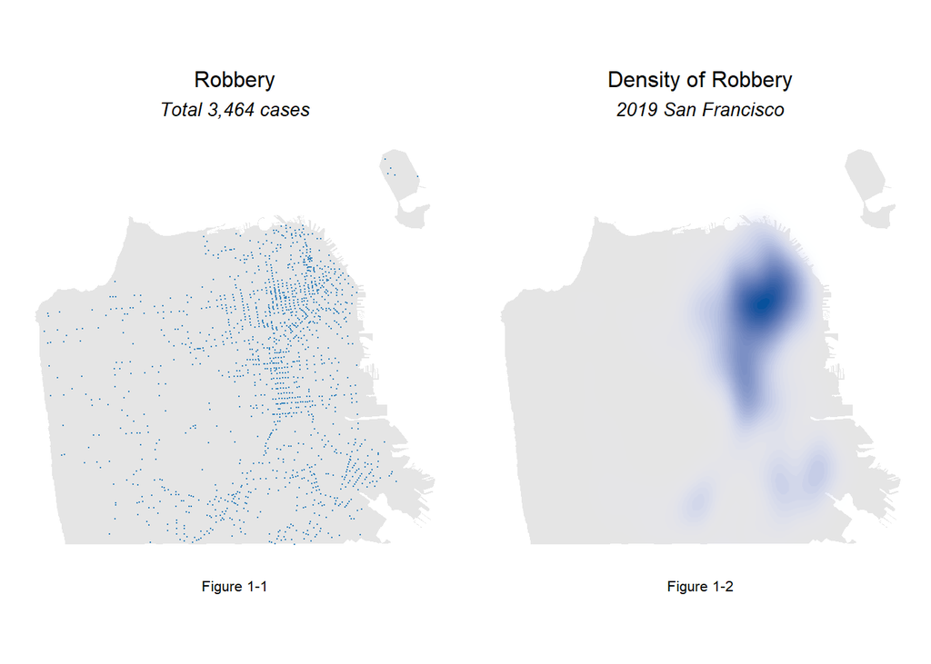

```r
grid.arrange(ncol=2,
ggplot() +
  geom_sf(data = SF_boundary, fill = greyPalette5[2], color = "transparent", alpha = 0.5) +
  geom_sf(data = Robbery, colour=bluePalette5[4], size=0.1, show.legend = "point") +
  labs(title= "Robbery",
       subtitle = "Total 3,464 cases",
       caption = "Figure 1-1") +
  mapThememin(),

ggplot() +
  geom_sf(data = SF_boundary, fill = greyPalette5[2], color = "transparent", alpha = 0.5) +
  stat_density2d(data = data.frame(st_coordinates(Robbery)),
                 aes(X, Y, fill = ..level.., alpha = ..level..),
                 size = 0.1, bins = 40, geom = 'polygon') +
  scale_fill_gradient(low = bluePalette5[1], high = bluePalette5[5]) +
  scale_alpha(range = c(0.00, 1), guide = FALSE) +
  labs(title = "Density of Robbery",
       subtitle = "2019 San Francisco",
       caption = "Figure 1-2") +
  mapThememin() + theme(legend.position = "none"))
```

### 2.2 Join Robbery Data to the Fishnet

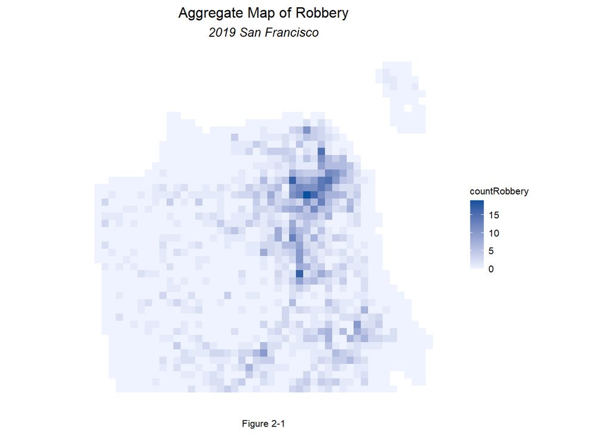

```r
crime_net <-
  dplyr::select(Robbery) %>%
  mutate(countRobbery = 1) %>%
  aggregate(., fishnet, sum) %>%
  mutate(countRobbery = replace_na(countRobbery, 0),
         uniqueID = 1:n(),
         cvID = sample(round(nrow(fishnet) / 24), size=nrow(fishnet), replace = TRUE))

# cross-validation id approx 100 folds

ggplot() +
  geom_sf(data = crime_net, aes(fill = countRobbery), color = "transparent")+
  # scale_fill_viridis() +
  scale_fill_gradient(low = bluePalette5[1], high = bluePalette5[5])+

  labs(title = "Aggregate Map of Robbery",
       subtitle = "2019 San Francisco",
       caption = "Figure 2-1") +
  mapThememin()
```

### 2.3 Multiple maps of Robbery risk factors

This section makes multiple maps of the risk factors to help us to understand the patterns geospatially. The six factors are all based on building environment characteristics: **Damaged Property**, **Homeless Concerns**, **Graffiti**, **Street_Lights**, **Sanitationa** and **Noise_Report**.

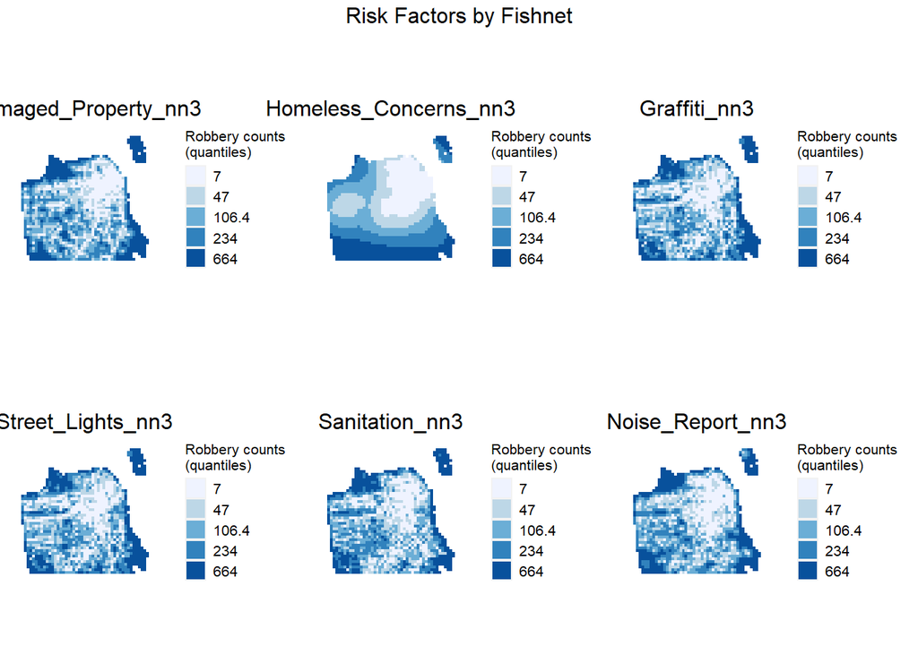

```r
vars_net <-
  rbind(rf1,rf2,rf3,rf4,rf5,rf6) %>%
  st_join(., fishnet, join=st_within) %>%
  st_drop_geometry() %>%
  group_by(uniqueID, Legend) %>%
  summarize(count = n()) %>%
    full_join(fishnet) %>%
    spread(Legend, count, fill=0) %>%
    st_sf() %>%
    dplyr::select(-`<NA>`) %>%
    na.omit() %>%
    ungroup()


vars_net <- vars_net %>%
    mutate(Damaged_Property_nn3 = round(nn_function(st_c(st_coid(vars_net)), st_c(rf1), k = 3)),
           Homeless_Concerns_nn3 = round(nn_function(st_c(st_coid(vars_net)), st_c(rf2), k = 3)),
           Graffiti_nn3 = round(nn_function(st_c(st_coid(vars_net)), st_c(rf3), k = 3)),
           Street_Lights_nn3 = round(nn_function(st_c(st_coid(vars_net)), st_c(rf4), k = 3)),
           Sanitation_nn3 = round(nn_function(st_c(st_coid(vars_net)), st_c(rf5), k = 3)),
           Noise_Report_nn3 = round(nn_function(st_c(st_coid(vars_net)), st_c(rf6), k = 3)))

vars_net.nn <-
  dplyr::select(vars_net, ends_with("nn3")) %>%
    gather(Variable, value, -geometry)

vars <- unique(vars_net.nn$Variable)
mapList <- list()


for(i in vars){
  mapList[[i]] <-
    ggplot() +
    geom_sf(data = filter(vars_net.nn, Variable == i), aes(fill=q5(value)), color = "transparent") +
    scale_fill_manual(values = bluePalette5,
                      labels = qBr(vars_net.nn, "value"),
                      name = "Robbery counts\n(quantiles)",
                      na.translate=FALSE) +
    labs(title = i) +
  mapThememin()
}

do.call(grid.arrange,c(mapList, ncol=3, top="Risk Factors by Fishnet"))
```

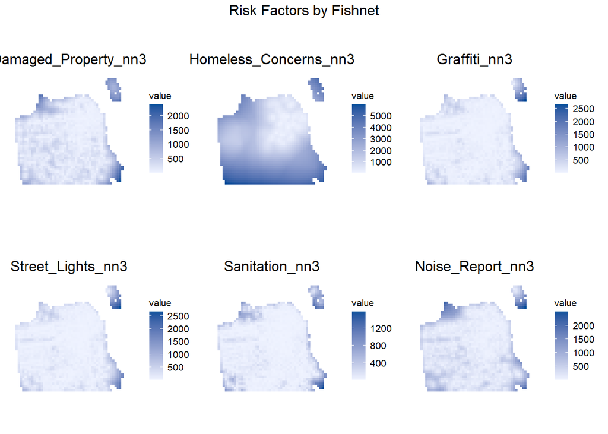

```r
for(i in vars){
  mapList[[i]] <-
    ggplot() +
    geom_sf(data = filter(vars_net.nn, Variable == i), aes(fill=value), color = "transparent") +
    scale_fill_gradient(low = bluePalette5[1], high = bluePalette5[5]) +
    labs(title = i) +
  mapThememin()
}

do.call(grid.arrange,c(mapList, ncol=3, top="Risk Factors by Fishnet"))
```

## 3. Spatial Patterns Exploration

### 3.1 Local Moran’s I Maps

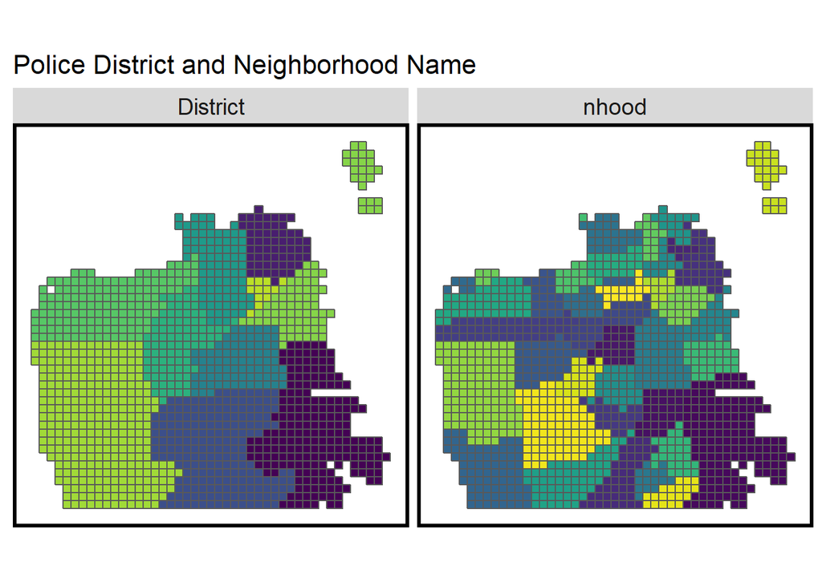

```r
final_net <-
  left_join(crime_net, st_drop_geometry(vars_net), by="uniqueID")

final_net <-
  st_centroid(final_net) %>%
    st_join(dplyr::select(SF_neighborhoods, nhood)) %>%
    st_join(dplyr::select(SF_policeDistricts, District)) %>%
      st_drop_geometry() %>%
      left_join(dplyr::select(final_net, geometry, uniqueID)) %>%
      st_sf() %>%
  na.omit()

dplyr::select(final_net, nhood, District) %>%
  gather(Variable, Value, -geometry) %>%
  ggplot() +
  geom_sf(aes(fill = Value)) +
  facet_wrap(~Variable) +
  scale_fill_viridis(discrete = TRUE) +
  labs(title = "Police District and Neighborhood Name") +
  mapTheme() + theme(legend.position = "none")
```

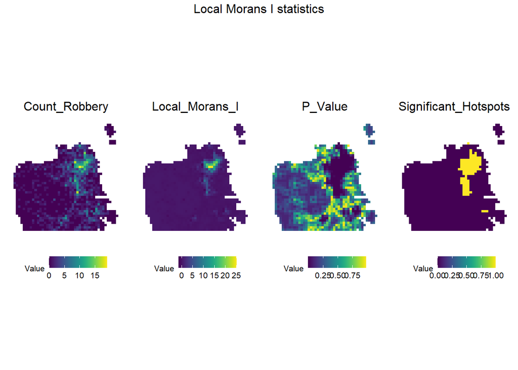

```r
final_net.nb <- poly2nb(as_Spatial(final_net), queen=TRUE)

final_net.weights <- nb2listw(final_net.nb, style="W", zero.policy=TRUE)

local_morans <- localmoran(final_net$countRobbery, final_net.weights, zero.policy=TRUE) %>%
  as.data.frame()

# join local Moran's I results to fishnet
final_net.localMorans <-
  cbind(local_morans, as.data.frame(final_net)) %>%
  st_sf() %>%
  dplyr::select(Count_Robbery = countRobbery,
                Local_Morans_I = Ii,
                P_Value = `Pr(z != E(Ii))`) %>%
  mutate(Significant_Hotspots = ifelse(P_Value <= 0.001, 1, 0)) %>%
  gather(Variable, Value, -geometry)

vars2 <- unique(final_net.localMorans$Variable)
varList2 <- list()

for(i in vars2){
  varList2[[i]] <-
    ggplot() +
    geom_sf(data = filter(final_net.localMorans, Variable == i), aes(fill=Value), color = "transparent") +
    scale_fill_viridis() +
    labs(title = i) +
  mapThememin() + theme(legend.position="bottom")}


do.call(grid.arrange,c(varList2, ncol = 4, top = "Local Morans I statistics"))
```

```r
final_net <-
  final_net %>%
  mutate(robbery.isSig = ifelse(local_morans[,5] <= 0.001, 1, 0)) %>%
  mutate(robbery.isSig.dist = nn_function(st_c(st_coid(final_net)), st_c(st_coid(filter(final_net, robbery.isSig == 1))), k = 1))
```

I measured the distance from each grid cells to its nearest highly significant cluster, which is the hotspot. The map below can tell us the areas relatively near and away from the significant clusters.

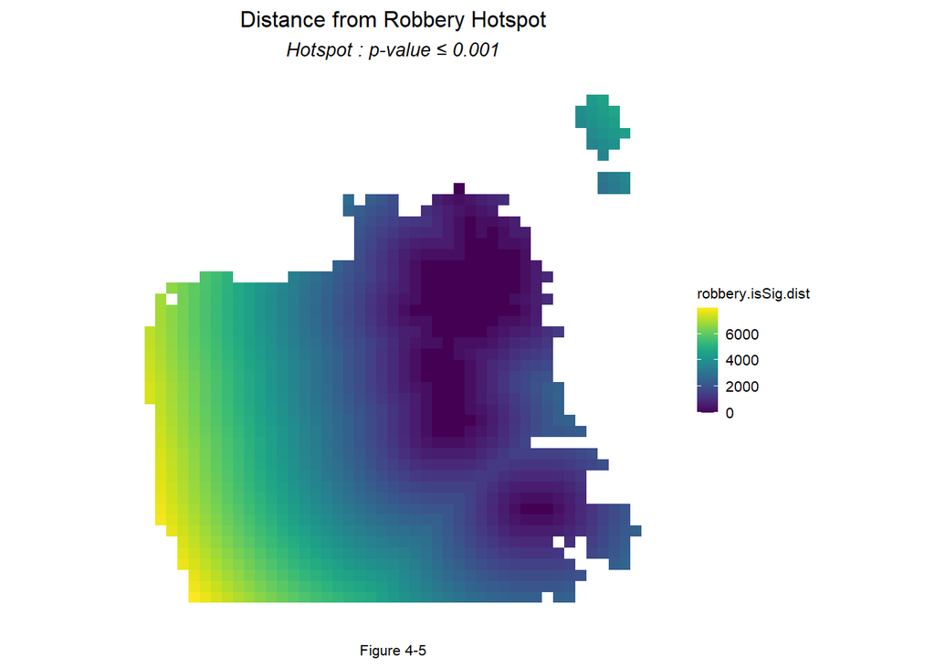

```r
ggplot() +
  geom_sf(data = final_net, aes(fill=robbery.isSig.dist), color = "transparent") +
  scale_fill_viridis() +
  labs(title = "Distance from Robbery Hotspot",
       subtitle = "Hotspot : p-value ≤ 0.001",
       caption = "Figure 4-5") +
  mapThememin()
```

### 3.2 Correlation Tests

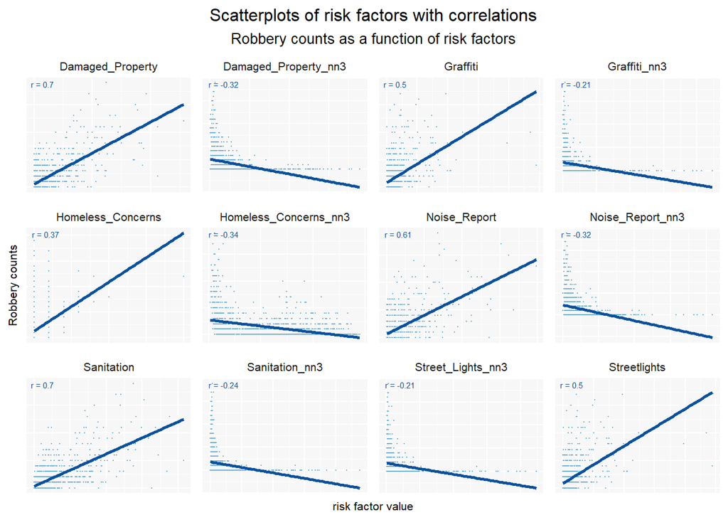

```r
correlation.long <-
  st_drop_geometry(final_net) %>%
    dplyr::select(-uniqueID, -cvID, -nhood, -District, -robbery.isSig, -robbery.isSig.dist) %>%
    gather(Variable, Value, -countRobbery)

correlation.cor <-
  correlation.long %>%
    group_by(Variable) %>%
    summarize(correlation = cor(Value, countRobbery, use = "complete.obs"))

ggplot(correlation.long, aes(Value, countRobbery)) +
  geom_point(size = 0.1, color = bluePalette5[3])  +
  geom_text(data = correlation.cor, aes(label = paste("r =", round(correlation, 2))),
            x=-Inf, y=Inf, vjust = 1.5, hjust = -.2, size = 2, color = bluePalette5[5]) +
  geom_smooth(method = "lm", se = FALSE, colour = bluePalette5[5]) +
  facet_wrap(~Variable, ncol = 4, scales = "free") +
  labs(title = "Scatterplots of risk factors with correlations",
       subtitle = "Robbery counts as a function of risk factors",
       x = "risk factor value",
       y = "Robbery counts") +
  corTheme()
```

### 3.3 Regression Model: Poisson Regression

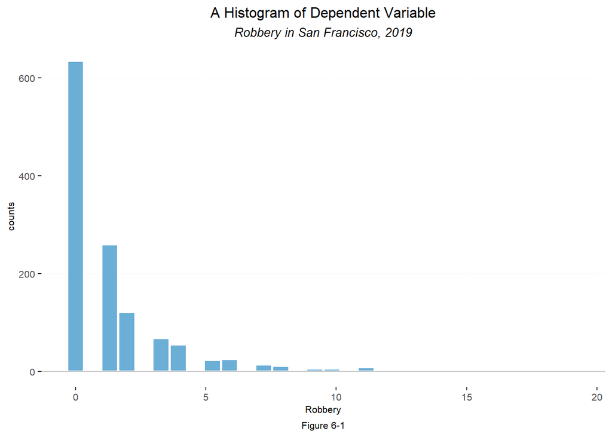

```r
ggplot(final_net, aes(x = countRobbery))+
  geom_histogram(fill=bluePalette5[3], color = "white", size = 1) +
  labs(title = "A Histogram of Dependent Variable",
       subtitle = "Robbery in San Francisco, 2019",
       x = "Robbery",
       y = "counts",
       caption = "Figure 6-1")+
  geom_hline(yintercept = 0, size = 0.5, color = greyPalette5[2]) +
  corTheme2()+
  theme(panel.background = element_blank(),
        panel.grid.major.y = element_line(size = 0.3, color = greyPalette5[1]))
```

### 3.4 Spatial Cross Validation

We need to perform spatial cross-validation to evaluate the generalizability of our model, the prediction at neighborhood in general is pretty hard, as Robbery could be location-specific. To solve this problem, I used Leave-one-group-out cross-validation (LOGO-CV), where a specific location is held out and predicted for by the model generated based on the remaining areas.

Then, we calculated the mean error of each methods. The map and plot results are as follows. As you can see, the predictions created by regression model that include the spatial structure factors appear to perform better.

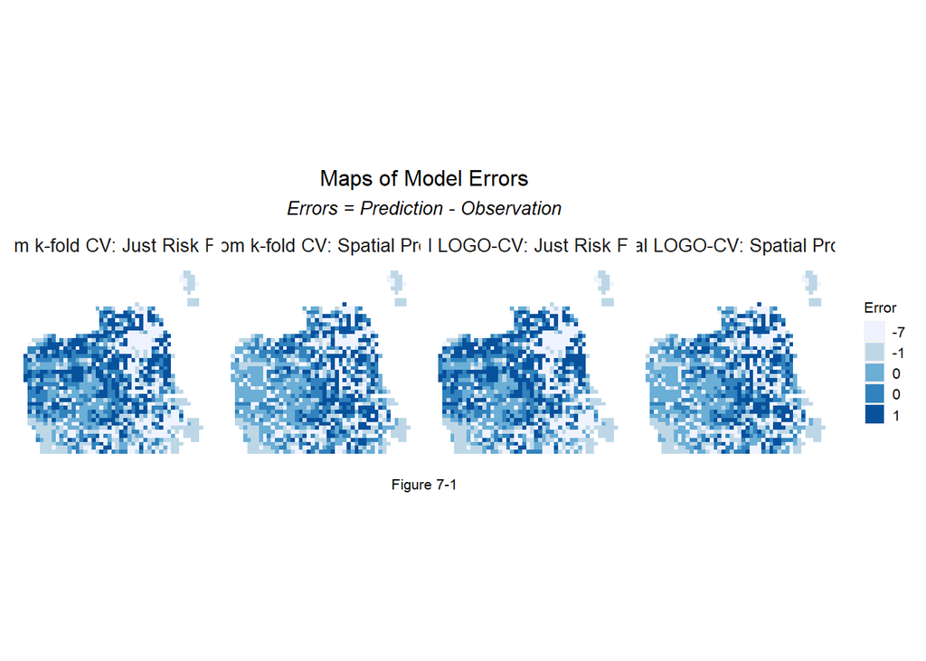

```r
## Defined the variables we want, two types

reg.vars <- c("Damaged_Property_nn3", "Homeless_Concerns_nn3", "Graffiti_nn3",
              "Street_Lights_nn3", "Noise_Report_nn3", "Sanitation_nn3")

reg.ss.vars <- c("Damaged_Property_nn3", "Homeless_Concerns_nn3", "Graffiti_nn3",
              "Street_Lights_nn3", "Noise_Report_nn3", "Sanitation_nn3", "robbery.isSig", "robbery.isSig.dist")

# 100 fold regression

reg.cv <- crossValidate(
  dataset = final_net,
  id = "cvID",
  dependentVariable = "countRobbery",
  indVariables = reg.vars) %>%
    dplyr::select(cvID = cvID, countRobbery, Prediction, geometry)

reg.ss.cv <- crossValidate(
  dataset = final_net,
  id = "cvID",
  dependentVariable = "countRobbery",
  indVariables = reg.ss.vars) %>%
    dplyr::select(cvID = cvID, countRobbery, Prediction, geometry)

# neighborhood fold regression

reg.spatialCV <- crossValidate(
  dataset = final_net,
  id = "nhood",
  dependentVariable = "countRobbery",
  indVariables = reg.vars) %>%
    dplyr::select(cvID = nhood, countRobbery, Prediction, geometry)

reg.ss.spatialCV <- crossValidate(
  dataset = final_net,
  id = "nhood",
  dependentVariable = "countRobbery",
  indVariables = reg.ss.vars) %>%
    dplyr::select(cvID = nhood, countRobbery, Prediction, geometry)

## Summary

reg.summary <-
  rbind(
    mutate(reg.cv,
           Error = Prediction - countRobbery,
           Regression = "Random k-fold CV: Just Risk Factors"),
    mutate(reg.ss.cv,
           Error = Prediction - countRobbery,
           Regression = "Random k-fold CV: Spatial Process"),

    mutate(reg.spatialCV,
           Error = Prediction - countRobbery,
           Regression = "Spatial LOGO-CV: Just Risk Factors"),

    mutate(reg.ss.spatialCV,
           Error = Prediction - countRobbery,
           Regression = "Spatial LOGO-CV: Spatial Process")) %>%
    st_sf()

ggplot(reg.summary) +
  geom_sf(aes(fill = q5(Error)), color = "transparent" ) +
  scale_fill_manual(values = bluePalette5,
                    labels = qBr(reg.summary, "Error"),
                    name = "Error",
                    na.translate=FALSE) +
  labs(title = "Maps of Model Errors",
       subtitle = "Errors = Prediction - Observation",
       caption = 'Figure 7-1') +
  facet_wrap(c(~Regression), ncol=4) +
  mapThememin()
```

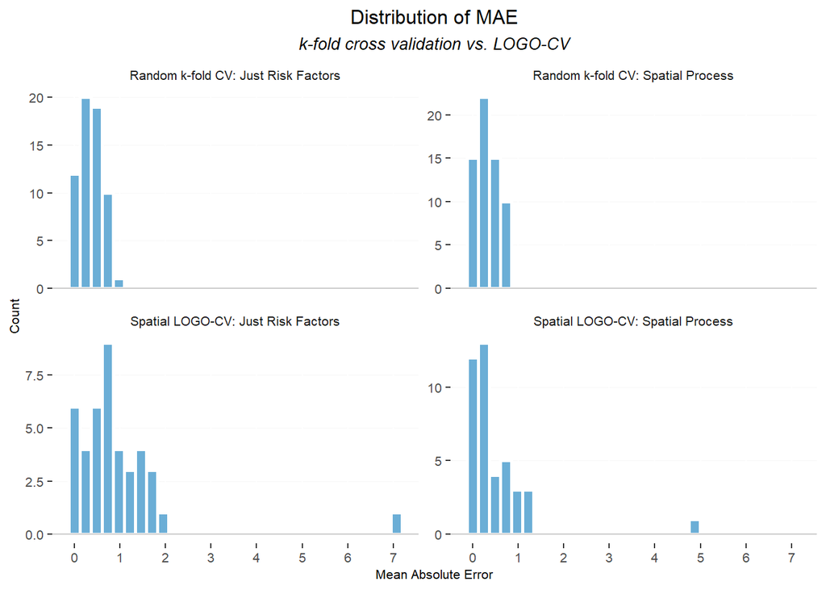

```r
error_by_reg_and_fold <-
  reg.summary %>%
    group_by(Regression, cvID) %>%
    summarize(Mean_Error = mean(Prediction - countRobbery, na.rm = T),
              MAE = mean(abs(Mean_Error), na.rm = T),
              SD_MAE = mean(abs(Mean_Error), na.rm = T)) %>%
  ungroup()

error_by_reg_and_fold %>%
  ggplot(aes(MAE)) +
  geom_histogram(bins = 30,  color = "white", size = 1, fill=bluePalette5[3]) +
  facet_wrap(~Regression, scales = "free_y") +
  geom_hline(yintercept = 0, size = 0.5, color = greyPalette5[2]) +
  scale_x_continuous(breaks = seq(0, 12, by = 1)) +
  labs(title="Distribution of MAE", subtitle = "k-fold cross validation vs. LOGO-CV",
       x="Mean Absolute Error", y="Count") +
  corTheme2() +
  theme(panel.background = element_blank(),
        panel.grid.major.y = element_line(size = 0.3, color = greyPalette5[1]))
```

What’s more, I calculated standard deviation of MAE, like the table below.

```r
st_drop_geometry(error_by_reg_and_fold) %>%
  group_by(Regression) %>%
    summarize(Mean_MAE = round(mean(MAE), 2),
              SD_MAE = round(sd(MAE), 2)) %>%
  kable(caption = "<center><span style='font-size:12px; color: black; font-family: Arial;'>Table 8-1. MAE and standard deviation MAE by regression</span>", align = "c") %>%
    kable_minimal(full_width = T, html_font = "Arial", font_size = 14) %>%
    row_spec(2, color = greyPalette5[5], background = bluePalette5[2], bold = T) %>%
    row_spec(4, color = greyPalette5[5], background = bluePalette5[2], bold = T) %>%
    row_spec(0:4, extra_css = "line-height: 30px")
```

Table 8-1. MAE and standard deviation MAE by regression

| Regression | Mean_MAE | SD_MAE |
| --- | --- | --- |
| Random k-fold CV: Just Risk Factors | 0.37 | 0.24 |
| Random k-fold CV: Spatial Process | 0.34 | 0.23 |
| Spatial LOGO-CV: Just Risk Factors | 0.93 | 1.12 |
| Spatial LOGO-CV: Spatial Process | 0.49 | 0.78 |

### 3.5 Neighborhood Context

When describing a neighborhood context, racial makeup is one of the most common demographic features. So I used census tract data, extracted the racial makeup, split the neighborhood into “Majority_White” and “Majority_Non_White” according to the percentage of White.

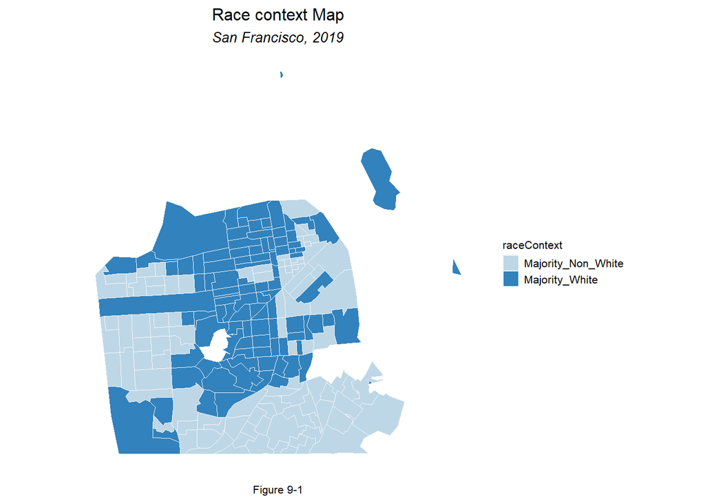

```r
census_var2019 <- c("B25026_001E", "B02001_002E", "B19013_001E", "B25058_001E", "B06012_002E")
SF.tracts19 <- get_acs(geography = "tract",
                           variables = census_var2019,
                           year=2019,
                           state="CA",
                           county= "San Francisco",
                           geometry=TRUE,
                           output="wide") %>%
    dplyr::select(-geometry, -B25026_001M, -B02001_002M, -B19013_001M, -B25058_001M, -B06012_002M) %>% # Remove margin of error columns
    st_transform('EPSG:7131') %>%
  rename(TotalPop = B25026_001E,
         Whites = B02001_002E,
         MedHHInc = B19013_001E,
         MedRent = B25058_001E,
         TotalPoverty = B06012_002E) %>%
  mutate(pctWhite = ifelse(TotalPop > 0, Whites / TotalPop,0),
         pctPoverty = ifelse(TotalPop > 0, TotalPoverty / TotalPop, 0),
         year = "2019") %>%
  mutate(pctWhite.scaled = pctWhite * 100,
         pctPoverty.scaled = pctPoverty * 100,
         raceContext = ifelse(pctWhite > .5, "Majority_White", "Majority_Non_White")) %>%
  dplyr::select(-Whites, -TotalPoverty, -NAME) %>%
  na.omit()

ggplot() +
  geom_sf(data = SF.tracts19, aes(fill = raceContext), color = greyPalette5[1], size = 0.1) +
  scale_fill_manual(values=c(bluePalette5[2], bluePalette5[4])) +
  labs(title = "Race context Map",
       subtitle = "San Francisco, 2019",
       caption = "Figure 9-1") +
  mapThememin()
```

```r
raceContext <-
  reg.summary %>%
  st_centroid() %>%
  st_join(SF.tracts19) %>%
  na.omit() %>%
  st_drop_geometry() %>%
  group_by(Regression, raceContext) %>%
  summarize(mean.Error = mean(Error, na.rm = T)) %>%
  spread(raceContext, mean.Error) %>%
  kable(caption = "<center><span style='font-size:12px; color: black; font-family: Arial;'>Table 9-1. Mean Error by Neighborhood Racial Context</span>", align = "c") %>%
  kable_minimal(full_width = T, html_font = "Arial", font_size = 13) %>%
  row_spec(2, color = greyPalette5[5], background = bluePalette5[2], bold = T) %>%
  row_spec(4, color = greyPalette5[5], background = bluePalette5[2], bold = T) %>%
  row_spec(0:4, extra_css = "line-height: 30px")

raceContext
```

Table 9-1. Mean Error by Neighborhood Racial Context

| Regression | Majority_Non_White | Majority_White |
| --- | --- | --- |
| Random k-fold CV: Just Risk Factors | -0.4038971 | 0.4334245 |
| Random k-fold CV: Spatial Process | -0.2719952 | 0.2814451 |
| Spatial LOGO-CV: Just Risk Factors | -0.4344369 | 0.4304895 |
| Spatial LOGO-CV: Spatial Process | -0.2935640 | 0.2910221 |

### 3.6 Comparsion and Predictions

The maps below shows the comparsion of kernel density of robbery and predictions in 2020. It turned out that the Risk Prediction Regression with LOGO-CV is a stronger fit for the high risk categories.

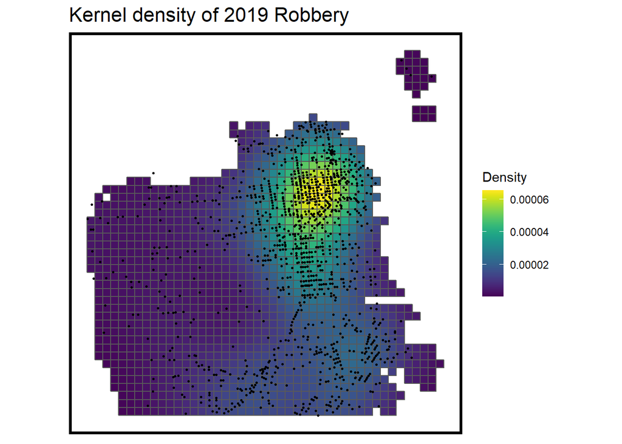

```r
robbery_ppp <- as.ppp(st_coordinates(Robbery), W = st_bbox(final_net))
robbery_KD.1000 <- spatstat.core::density.ppp(robbery_ppp, 1000)

as.data.frame(robbery_KD.1000) %>%
  st_as_sf(coords = c("x", "y"), crs = st_crs(final_net)) %>%
  aggregate(., final_net, mean) %>%
   ggplot() +
     geom_sf(aes(fill=value)) +
     geom_sf(data = sample_n(Robbery, 1500), size = .5) +
     scale_fill_viridis(name = "Density") +
     labs(title = "Kernel density of 2019 Robbery") +
     mapTheme()
```

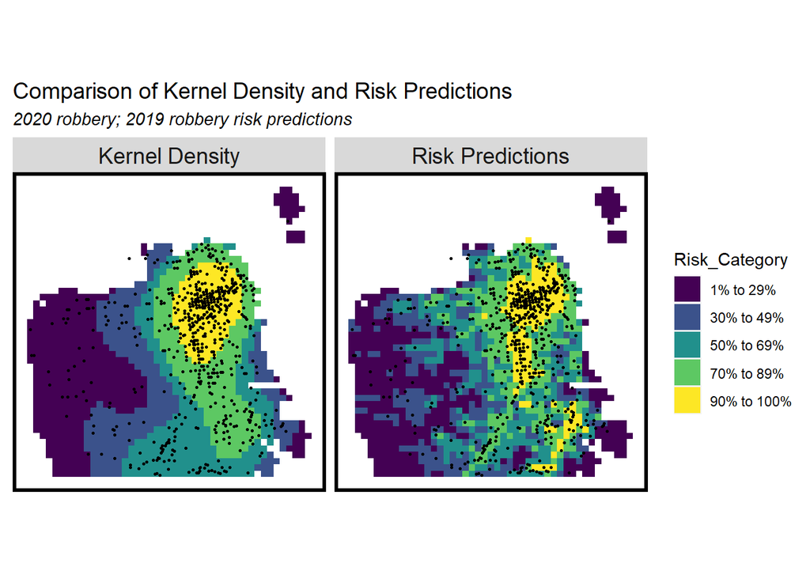

```r
Criminals20 <-
  st_read("./data/Crime_2020.geojson")%>%
  st_transform('EPSG:7131')


Robbery20 <-
  Criminals20 %>%
  filter(incident_category == "Robbery") %>%
  na.omit() %>%
  st_transform('EPSG:7131') %>%
  distinct() %>%
  .[fishnet,]


robbery_KDE_sum <- as.data.frame(robbery_KD.1000) %>%
  st_as_sf(coords = c("x", "y"), crs = st_crs(final_net)) %>%
  aggregate(., final_net, mean)

kde_breaks <- classIntervals(robbery_KDE_sum$value,
                             n = 5, "fisher")
robbery_KDE_sf <- robbery_KDE_sum %>%
  mutate(label = "Kernel Density",
         Risk_Category = ntile(value, 100),
         Risk_Category = case_when(
           Risk_Category >= 90 ~ "90% to 100%",
           Risk_Category >= 70 & Risk_Category <= 89 ~ "70% to 89%",
           Risk_Category >= 50 & Risk_Category <= 69 ~ "50% to 69%",
           Risk_Category >= 30 & Risk_Category <= 49 ~ "30% to 49%",
           Risk_Category >= 1 & Risk_Category <= 29 ~ "1% to 29%")) %>%
  cbind(
    aggregate(
      dplyr::select(Robbery20) %>% mutate(robberyCount = 1), ., sum) %>%
    mutate(robberyCount = replace_na(robberyCount, 0))) %>%
  dplyr::select(label, Risk_Category, robberyCount)

robbery_risk_sf <-
  reg.ss.spatialCV %>%
  mutate(label = "Risk Predictions",
         Risk_Category = ntile(Prediction, 100),
         Risk_Category = case_when(
         Risk_Category >= 90 ~ "90% to 100%",
         Risk_Category >= 70 & Risk_Category <= 89 ~ "70% to 89%",
         Risk_Category >= 50 & Risk_Category <= 69 ~ "50% to 69%",
         Risk_Category >= 30 & Risk_Category <= 49 ~ "30% to 49%",
         Risk_Category >= 1 & Risk_Category <= 29 ~ "1% to 29%")) %>%
  cbind(
    aggregate(
      dplyr::select(Robbery20) %>% mutate(robberyCount = 1), ., sum) %>%
      mutate(robberyCount = replace_na(robberyCount, 0))) %>%
  dplyr::select(label,Risk_Category, robberyCount)

rbind(robbery_KDE_sf, robbery_risk_sf) %>%
  na.omit() %>%
  gather(Variable, Value, -label, -Risk_Category, -geometry) %>%
  ggplot() +
    geom_sf(aes(fill = Risk_Category), colour = NA) +
    geom_sf(data = sample_n(Robbery20, 1000), size = .5, colour = "black") +
    facet_wrap(~label, ) +
    scale_fill_viridis(discrete = TRUE) +
    labs(title="Comparison of Kernel Density and Risk Predictions",
         subtitle="2020 robbery; 2019 robbery risk predictions") +
    mapTheme(title_size = 14)
```

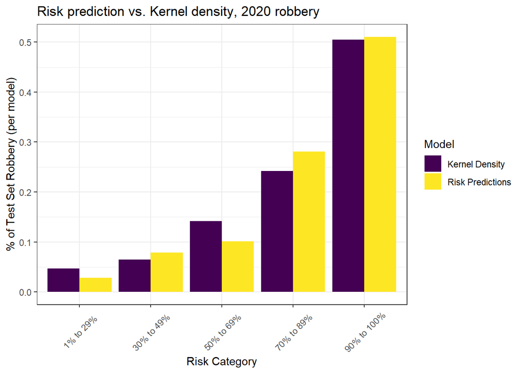

```r
rbind(robbery_KDE_sf, robbery_risk_sf) %>%
  st_drop_geometry() %>%
  na.omit() %>%
  gather(Variable, Value, -label, -Risk_Category) %>%
  group_by(label, Risk_Category) %>%
  summarize(countRobbery = sum(Value)) %>%
  ungroup() %>%
  group_by(label) %>%
  mutate(Pcnt_of_test_set_crimes = countRobbery / sum(countRobbery)) %>%
    ggplot(aes(Risk_Category,Pcnt_of_test_set_crimes)) +
      geom_bar(aes(fill=label), position="dodge", stat="identity") +
      scale_fill_viridis(discrete = TRUE, name = "Model") +
      labs(title = "Risk prediction vs. Kernel density, 2020 robbery",
           y = "% of Test Set Robbery (per model)",
           x = "Risk Category") +
  theme_bw() +
      theme(axis.text.x = element_text(angle = 45, vjust = 0.5))
```

## 4. Results

In conclusion, the geospatial risk prediction model I proposed used six building environment factors and the spatial patterns to predict the robbery. The cross validation process suggested that spatial patterns is helpful in making our model more generalizable, but the neighborhood context test suggested that it would tend to over predict or under predict neighborhood with different racial makeup.

What’s more, our model’s mean absolute error is pretty low, which means a good accuracy, especially when consider the spatial patterns. But there are some limitations, from the table’s reult in risk category, the performance is not so good in the mid risk category. Nevertheless, due to the fair generalizability and high accuracy, I would recommend our model to the San Francisco Police Department as a reference.